# 第四章：数据可视化 2: 空间制图

##### 制图规范

###### **5.2 地图美化**

可参考第三章可视化美化内容

在第三章中，本教程已系统探讨了数据可视化的**通用**美学原则。然而，地图包含复杂的地理基底与多维度的空间拓扑关系，其美化逻辑具有极强的**特殊性**。

> 必须明确的核心前提是：**所有地图的美化，都必须建立在绝对严谨的“制图规范”基础之上**。

精心打磨的地图“颜值”并非仅为视觉愉悦。在学术报告、政策简报或商业竞标中，**高品质的空间可视化**能够显著提升作品的专业度与可信度，一定程度上可提高研究的**录用倾向**或**项目的中标率**。

针对空间制图，核心的美化与版式原则主要包括以下**三个**维度：

**1. 视觉层级与底图退隐**

与普通统计图表不同，地图的画板通常是广袤且复杂的地理空间。

在**常见**的空间制图中，必须确保**核心数据图层**处于**视觉最前端**。底图（如行政边界、地形或路网）仅提供**空间参考**，建议使用低饱和度、低对比度的中性色调（如浅灰色 `#F5F5F5` 或暗黑色 `#1A1A1A`）予以视觉弱化。同时，面要素的边界线（Borders）宜采用极细且贴近底色的线条（或直接取消边界），以有效消解画面的割裂感。

> 在高精度微观地理尺度下（如英国 OA、美国 Census Tract 或 Block Group 级别），建议**直接取消面要素的边界绘制**，这能有效避免密集边界线对分层设色视觉表达的严重干扰。

**2. 空间拥挤的视觉消解**

当进行空间大数据制图时（如海量的**微观定位点**或 **OD 轨迹线**），若直接将原始要素映射到图面上，在局部高度聚集的区域极易产生**空间拥挤与遮挡**（Overplotting）。这种缺乏修饰的粗暴映射不仅会导致**底图被严重遮挡、画面糊成一团**丧失美感，更会掩盖数据本身的绝对密度差异，使得图面完全无法有效传达出空间分布的“冷热点”信息。

为了精准展现真实的空间聚集特征并兼顾制图美学，推荐采用以下策略：

- **透明度叠加与暗场发光**：  
  在暗色背景基底上，为数据要素设置**极高的透明度**与**高明度色彩**。依托海量点位或轨迹线的物理重叠与色彩累加，自然透出高亮光晕（即**“伪热力发光”**效果）。此方法能够在完全保留原始空间结构的同时，通过亮度差异直观反映出热点区域。

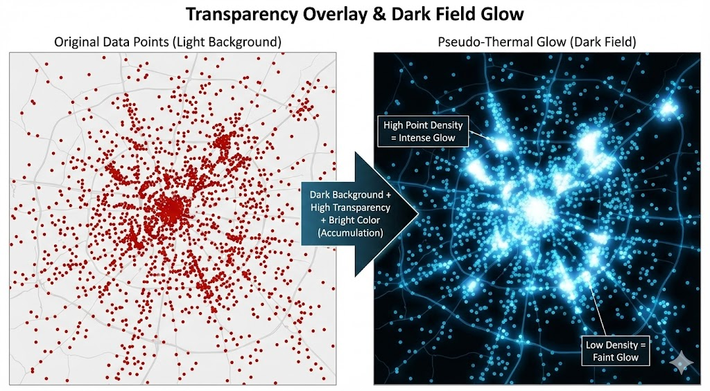

Figure 13 透明度叠加与暗场发光示意图

- **既有空间单元聚合**（Spatial Aggregation）：  
  将微观离散点位直接归集至既有行政或统计单元（如英国的 OA、LSOA 或美国的 Census Tract）。通过执行空间连接（Spatial Join）或拓扑相交运算（`st_intersects`）汇总地块内的要素频数。为消除各单元因面积或人口基数悬殊造成的统计偏差，强烈建议将基础频数转化为**空间密度**或**人均指标**，再进行分层设色图的渲染。

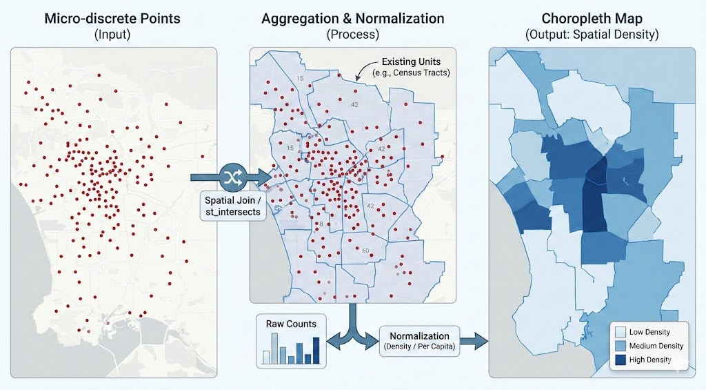

Figure 14 空间单元聚合示意图

- **几何网格聚合**（Tessellation & Binning）：  
  果断放弃散点映射，将地理空间划分为标准化的聚合单元（如六边形或正方形密铺网格），并统计网格内包含的要素频数或属性指标。辅以连续或离散的渐变色带进行分层设色，能有效规避相互遮挡，极大提升分布密度的精确可读性与学术严谨度。

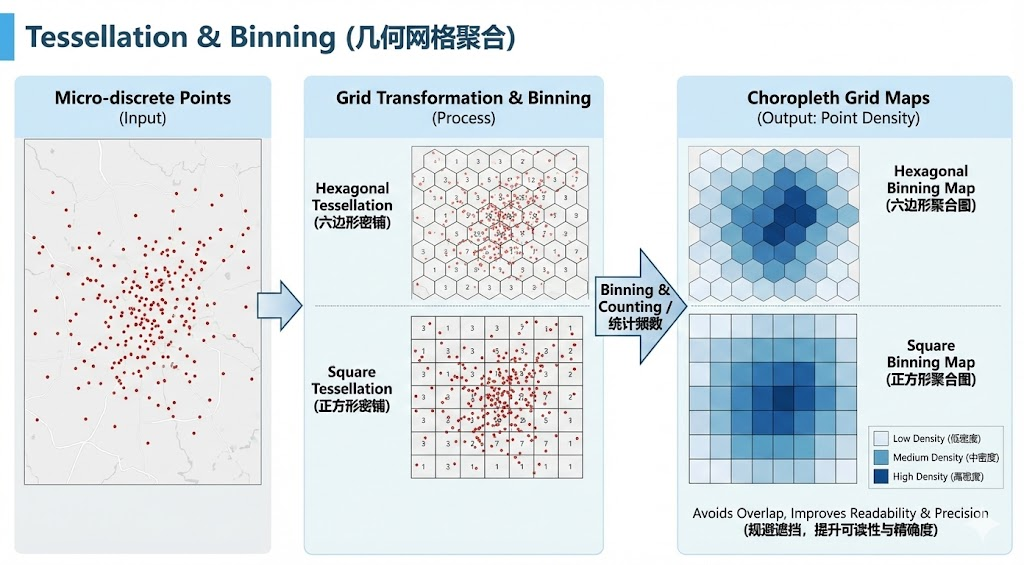

Figure 15 几何网格聚合示意图

- **核密度估计**（Kernel Density Estimation, KDE）：  
  运用空间统计学算法，将离散的点集直接转化为平滑、连续的密度表面分布图。此方法能极其精准且柔和地刻画出空间“热点”的渐变轮廓与核心区范围（注：核密度图通常涉及 raster 栅格数据格式的处理，本节仅作概念提及，不作代码展开）。

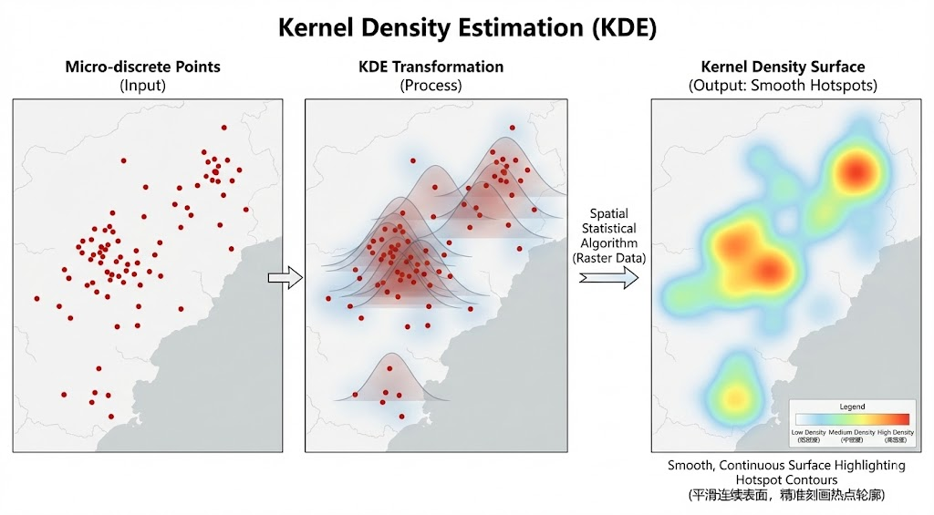

Figure 16 核密度估计示意图

**3. 制图辅助要素的主题融合与版式一致性**

地图的三大辅助要素（比例尺、指北针、图例）不仅是测绘规范组件，更是排版设计的有机组成部分。首先，需根据地图底色动态适配其视觉对比度。其次，对于长条形的连续型或离散化统计图例，推荐采用**底部水平居中**的排版方式，这能与地图整体的横竖向比例形成视觉配平，避免侧边垂直放置挤占核心图幅的有效空间。

此外，尽管 `ggspatial` 等扩展包提供了种类繁多的指北针与比例尺样式，但在同一项研究或同一份报告中，务必保持**出图风格的高度一致性**。这意味着不同地图间的辅助要素样式、所处位置、颜色搭配以及经纬线风格应严格统一，这也精准契合了数据可视化中对颜色与字体一致性的核心要求（参考第三章内容）。

#### **扩展学习与灵感资源**

空间制图美学需要持续的阅图积累与代码实践。以下精选了涵盖技术指南、制图工具与前沿灵感的高质量资源：

**1. R 语言空间制图权威指南**  
- **Geocomputation with R**（[第 9 章：Making maps](https://r.geocompx.org/adv-map)）：R 语言空间分析开源教科书，系统讲解了静态与交互式高级地图的绘制规范。  
- **ggplot2: Elegant Graphics for Data Analysis**（[第 6 章：Maps](https://ggplot2-book.org/maps.html)）：`ggplot2` 官方指南地图专章，深度剖析空间矢量渲染与投影几何逻辑。

**2. 经典工具与学术范例**  
- **ColorBrewer 2.0** (colorbrewer2.org)：专为地图设计的经典配色基准工具，支持“色盲友好”与“打印友好”等科学筛选。  
- **DataShine** (datashine.org.uk)：英国 UCL 团队开发的人口普查可视化平台，是微观尺度（如 OA 级别）高精度分层设色地图的顶级参考。

**3. 制图美学与艺术灵感**  
- **London: The Information Capital**（James Cheshire & Oliver Uberti）：城市空间可视化的标杆级专著，展示了如何将海量城市数据转化为极致的制图艺术。  
- **David Rumsey Map Collection** (davidrumsey.com)：全球最大历史古地图库，可从中汲取传统制图学的文本排版与古典色彩美学沉淀。  
- **#30DayMapChallenge**（GitHub/X 检索同名标签）：每年 11 月由全球空间数据社区发起的开源制图挑战，汇集大量前卫设计灵感与复现代码。

**© 华东师范大学 社会发展学院 人口研究所** | [**DAWN 研究组**](https://dawn-ecnu.github.io) | yzliu@soci.ecnu.edu.cn

课程负责人：刘贇喆 本章作者：刘贇喆

最后更新：2026年03月26日 构建环境：R version 4.5.2 (2025-10-31)

[CC BY-NC-SA 4.0](https://creativecommons.org/licenses/by-nc-sa/4.0/deed.zh) 回到顶部

## **6.0 本章练习**

### **6.0 动手实战**

实战目标

本节练习使用 **Inside Airbnb** 提供的开源真实房源数据与 `spData` 包中的大伦敦行政区数据，进行多图层与多尺度的空间可视化分析：

（1）以**网络读取**方式获取房源观测值，清洗并转化为空间点要素（`st_as_sf`），与面要素执行**地理坐标对齐**（`st_transform`）；  
（2）出图 1 绘制**暗夜发光风格**的点分布地图，对高密度空间点要素进行层次化渲染（点径与透明度控制）；  
（3）出图 2 构建六边形空间网格（Hexagonal Tessellation），执行**空间拓扑关联**（Point-in-Polygon）与均值过滤，并应用 **Fisher-Jenks 自然断点法**绘制学术规范的分层设色图（含几何计算与视觉呈现的坐标系逆向对齐逻辑）。

将巩固以下能力：  
- **空间数据流处理**：远程数据抓取、二维坐标映射、CRS 投影系统转换与逆向对齐。  
- **空间统计与聚合**：标准几何网格生成、基于空间相交特征的频数计算与阈值过滤。  
- **制图美学与规范**：高密度数据的过度绘制规避策略、离散数据分级表达、多主题（暗场/亮场）图面排版定制。

#### **6.1 数据与研究问题设定**

**数据来源**：  
1. `Inside Airbnb` 全球短租房源开源数据（本练习选取大伦敦地区，含经纬度坐标的 `.gz` 完整版房源切片数据）。  
2. `spData::lnd` 大伦敦区行政边界矢量面数据。

#### **数据说明：Inside Airbnb 与 `lnd` 面数据**

- **Inside Airbnb** (https://insideairbnb.com/get-the-data/) 是一个独立的**非商业开源项目**，旨在探究并揭示短期租赁平台对全球城市住宅社区的真实影响。该平台定期抓取并发布全球主要城市的详尽短租数据，字段涵盖完整的房源属性、空间坐标、日历可用性及用户历史评论等（本练习仅调用伦敦地区最新一期的全量房源属性与坐标数据）。此类高精度微观数据目前已被广泛应用于城市空间结构、住房政策评估等领域的量化研究中。
- **`lnd`** 是 `spData` 教学包中内置的经典空间数据集，包含了伦敦各行政区（Boroughs）的边界多边形。

**研究任务**：

- **制图任务1｜微观空间形态与分类映射**（点分布图）：不同租赁类型（`room_type`）在城市空间中呈现何种微观分布特征？

  本任务要求清洗网络读取的源数据并生成 `sf` 对象。在**暗色基底**上，应用**“深空星云”配色方案**直接映射房源分布。通过**极小点径**与**高透明度**配置，自然生成类似热力聚集的**“发光”**图面。
- **制图任务2｜空间网格离散化与聚合统计**（六边形密铺分层设色图）：房源在标准物理空间单元**（约 0.5 km² 的六边形网格）**内的聚集强度如何？ 重要

  本任务需将底层数据转换至投影坐标系（EPSG:27700）以生成精确**面积的几何网格**。计算网格内的包含要素数量，过滤低于均值的单元，并采用 **Fisher-Jenks 法**进行 **7 级离散化**。最终需将网格逆向转换回地理坐标系（WGS 84），配合纯净明亮的学术主题输出空间密度图。

> 这是一个“照着做”的练习：先复现图形，再逐行理解每一层空间映射、拓扑运算与主题定制代码的底层逻辑。

**请在 R Project 中新建一个 R Markdown 文档：**

- 文件名建议：`Lab4_spatial_vis.Rmd`
- **核心要求**：
  1. 加载 `tidyverse`、`sf`、`spData`、`ggspatial` 与 `classInt` 包（未安装请先安装）。
  2. 使用 `read_csv()` 直接读取 Airbnb 的 `.gz` 网络数据，去除坐标缺失值，完成初始空间要素实例化与底图坐标对齐。
  3. **完成图 1 绘制**：叠加纯黑底色、暗灰边界与荧光色点要素，配置暗场主题（`theme_void` 深度定制）及相应制图标尺。
  4. **完成图 2 绘制**：
     - 执行投影转换生成六边形网格（`st_make_grid`）。
     - 利用 `st_intersects` 计算聚合数量，并保留高于均值的数据。
     - 使用 `classIntervals` 提取自然断点并分箱。
     - 逆向投影至 WGS 84 后，采用明亮学术主题与热力色偏映射离散密度，确保横向图例排版。
  5. 生成 `html` 输出，并检查两幅地图的学术规范性。

##### **6.2 可复现模板**

注意

> 从第三章开始，练习不再提供完整的 `.Rmd` 成品模板。  
> 练习要求是在**自建的 R Markdown 文档**中自行插入代码块并运行（可参考第2章的格式配置）。  
> 请参考本章前述小节的核心代码逻辑，逐步构建并完成两类不同风格与分析维度的城市空间制图。

#### **几何拓展：如何推算六边形的 `cellsize`？**

在执行空间离散化时，我们往往需要指定具有明确物理意义的网格面积（例如本案例的 $0.5\text{ km}^2$）。在 `sf::st_make_grid(square = FALSE)` 函数中，生成六边形网格所用的 `cellsize` 参数，指的是正六边形**对边之间的距离**（即内切圆直径 $d$）。

根据正六边形的面积公式，面积 $A$ 与对边距离 $d$ 的关系为：
$$A = \frac{\sqrt{3}}{2} d^2$$

假设我们需要生成一个面积精确为 **0.5 平方千米**（即 $500,000\text{ m}^2$）的六边形网格，通过逆向推导：
$$500,000 = \frac{\sqrt{3}}{2} d^2$$
$$d^2 = \frac{1,000,000}{\sqrt{3}} \approx
577,350.27$$
$$d = \sqrt{577,350.27}
\approx 759.835\text{ (m)}$$

因此，在代码中设定 `cellsize = 759.83`，即可精确生成面积约为 0.5 $\text{km}^2$ 的空间统计单元。

```r
# ============================================================
# 系统环境配置与核心依赖库加载
# ============================================================
library(tidyverse)
library(sf)
library(ggspatial)
library(spData)   # 提供大伦敦行政区划 (lnd) 边界数据集
library(classInt) # 执行 Fisher-Jenks 自然断点分类

# ============================================================
# 1. 远程获取与解析全量微观空间数据 (Remote Data Acquisition)
# ============================================================
# 指定由 Inside Airbnb 提供的 GZIP 压缩格式原始数据源
airbnb_gz_url <- "https://data.insideairbnb.com/united-kingdom/england/london/2025-09-14/data/listings.csv.gz"

# 依托 readr 引擎执行内存级解压与读取，直接将网络流解析为数据框 (DataFrame)
# 提示：由于样本量及属性维度较大，网络 I/O 耗时取决于当前连接带宽
london_airbnb_full <- read_csv(airbnb_gz_url)

# ============================================================
# 2. 空间对象实例化与数据清洗 (Spatial Object Instantiation)
# ============================================================
airbnb_sf <- london_airbnb_full %>%
  # 剔除坐标字段缺失的无效观测值，保障底层几何转换的稳健性
  filter(!is.na(longitude) & !is.na(latitude)) %>%
  # 将二维数值坐标映射为标准的几何点要素 (POINT)，并显式声明 WGS 84 (EPSG:4326) 坐标系
  st_as_sf(coords = c("longitude", "latitude"), crs = 4326)

# 检验实例化结果：确认 Simple feature collection 结构及其包含的属性字段
print(airbnb_sf)

# ============================================================
# 3. 载入基底要素与地理坐标系对齐 (Geographic CRS Alignment)
# ============================================================
# 载入基底多边形要素 (Polygon)：大伦敦各区边界 (默认使用 WGS 84 经纬度系统)
data("lnd", package = "spData")

# [空间拓扑原则] 强制投影对齐
# 确保点数据与基底面数据的坐标系完全一致，避免后续可视化产生空间漂移
airbnb_sf_transformed <- airbnb_sf %>%
  st_transform(crs = st_crs(lnd))

# ============================================================
# 4. 预设高对比度分类色谱 (Categorical Color Palette)
# ============================================================
# 针对高密度点群特征，构建基于暗场 (Dark Mode) 环境发光特性的定性色盘
# 旨在通过高饱和度冷暖对比，剥离不同房源类型在微观尺度下的空间异质性
nebula_colors <- c(
  "Entire home/apt" = "#00E5FF", # 荧光青
  "Private room"    = "#9D00FF", # 深空紫
  "Shared room"     = "#FF1493", # 炽热粉
  "Hotel room"      = "#FFD700"  # 星尘金
)

# ============================================================
# 5. [出图 1] 绘制暗夜发光主题的综合点面图 (Point Distribution)
# ============================================================
ggplot() +

  # --- 5.1 基础空间框架渲染 ---
  # 设定深色行政边界作为基底，降低边界亮度 (grey30) 以抑制对主体数据的视觉干扰
  geom_sf(data = lnd, fill = "black", color = "grey30", linewidth = 0.5) +

  # --- 5.2 核心要素空间映射 ---
  # 采用极小点径 (size = 0.01) 与低透明度 (alpha = 0.1) 策略控制过度绘制 (Overplotting)
  # 依托高密度区域的色彩物理叠加，自然生成伪热力聚集的视觉特征
  geom_sf(data = airbnb_sf_transformed,
          aes(color = room_type),
          size = 0.01,
          alpha = 0.1) +

  # --- 5.3 空间测量参考配置 ---
  annotation_north_arrow(location = "tl", which_north = "true",
                         pad_x = unit(.2, "in"), pad_y = unit(.2, "in"),
                         style = north_arrow_fancy_orienteering(text_col = "white",
                                                                line_col = "white",
                                                                fill = "white")) +
  annotation_scale(location = "bl", width_hint = 0.25,
                   text_col = "white", line_col = "white",
                   pad_x = unit(.2, "in"), pad_y = unit(.2, "in")) +

  # --- 5.4 视觉通道与图例配置 ---
  scale_color_manual(values = nebula_colors, name = "Room Type") +
  # 解耦图面与图例的尺寸映射，独立放大图例标示点以保障学术可读性
  guides(color = guide_legend(override.aes = list(size = 3, alpha = 1))) +

  # --- 5.5 空间范围裁切 (Bounding Box) ---
  coord_sf(xlim = st_bbox(lnd)[c("xmin", "xmax")],
           ylim = st_bbox(lnd)[c("ymin", "ymax")],
           expand = TRUE) +

  # --- 5.6 绘图引擎主题重构 ---
  theme_void() +
  theme(
    plot.background  = element_rect(fill = "black", color = NA),
    panel.background = element_rect(fill = "black", color = NA),
    panel.grid.major = element_line(color = "grey15", linetype = "dotted", linewidth = 0.4),

    axis.text  = element_text(color = "grey40", size = 7),
    axis.title = element_blank(),
    axis.ticks = element_blank(),

    legend.position   = "bottom",
    legend.background = element_rect(fill = "black", color = NA),
    legend.text       = element_text(color = "white"),
    legend.title      = element_text(color = "white", face = "bold"),

    plot.title    = element_text(color = "white", face = "bold", size = 16, hjust = 0.5, margin = margin(t = 15, b = 5)),
    plot.subtitle = element_text(color = "grey70", hjust = 0.5, margin = margin(b = 15)),
    plot.caption  = element_text(color = "grey50", hjust = 1, size = 8, margin = margin(t = 10)),
    plot.margin   = margin(10, 15, 10, 15)
  ) +

  labs(
    title = "Airbnb Spatial Distribution in London",
    subtitle = paste0("Total Listings: ", scales::comma(nrow(airbnb_sf)), " | Data Updated: 14 Sep 2025"),
    caption = "Data Source: Inside Airbnb & spData"
  )

# ============================================================
# 6. 空间网格离散化处理 (Hexagonal Tessellation & Classification)
# ============================================================

# 6.1 投影平面坐标系转换 (Projected CRS)
# 必须将数据转入英国国家格网系统 (BNG, EPSG:27700)，以便使用物理单位(米)进行几何面积分割
lnd_bng <- st_transform(lnd, crs = 27700)
airbnb_sf_bng <- st_transform(airbnb_sf_transformed, crs = 27700)

# 6.2 生成等面积六边形网格
# 在 BNG 投影下生成 cellsize = 759.83m 的网格，确保单体面积约为 0.5 km²
hex_grid <- st_make_grid(lnd_bng, cellsize = 759.83, square = FALSE) %>%
  st_sf(hex_id = 1:length(.))

# 6.3 执行点面拓扑关联 (Spatial Join Count)
# 计算每个六边形单元内包含的 Airbnb 房源总量
hex_grid$listing_count <- lengths(st_intersects(hex_grid, airbnb_sf_bng))

# 6.4 过滤低频统计噪声
# 采用均值过滤 (Mean filtering)，剔除零散区域，聚焦于高于平均分布密度的核心单元
hex_filtered <- hex_grid %>%
  filter(listing_count >= mean(hex_grid$listing_count))

# 6.5 执行 Fisher-Jenks 自然断点分类
# 将连续的数值划分为 7 个离散层级，旨在最大化组间空间异质性
jenks_breaks <- classIntervals(hex_filtered$listing_count, n = 7, style = "fisher")$brks

# 6.6 坐标系逆向转换 (Visual Alignment)
# 重要：将生成的网格与底图转回 WGS 84，以纠正 BNG 投影在大尺度下的视觉偏转，对齐标准水平经纬网
hex_viz <- hex_filtered %>%
  mutate(count_class = cut(listing_count, breaks = jenks_breaks, include.lowest = TRUE, dig.lab = 10)) %>%
  st_transform(crs = 4326)

lnd_viz <- st_transform(lnd_bng, crs = 4326)

# ============================================================
# 7. [出图 2] 空间分布密度可视化 (Scientific Map: Hexagonal Binning)
# ============================================================
ggplot() +

  # --- 7.1 行政基底渲染 ---
  # 使用中性色调 (Neutral tones) 构建背景，减少视觉冗余
  geom_sf(data = lnd_viz, fill = "#F5F5F5", color = "#CCCCCC", linewidth = 0.5) +

  # --- 7.2 核心密度网格渲染 ---
  # 采用带白色描边的多边形呈现清晰的蜂窝拓扑结构
  geom_sf(data = hex_viz,
          aes(fill = count_class),
          color = "white",
          linewidth = 0.1,
          alpha = 0.9) +

  # --- 7.3 视觉通道配置 (Visual Channels) ---
  scale_fill_viridis_d(option = "magma",
                       direction = -1,
                       name = "Number of Airbnb listing buildings \n(Natural Breaks)") +

  # 维持底部横向布局，适配多分类图例的展示张力
  guides(fill = guide_legend(nrow = 1,
                             title.position = "top",
                             title.hjust = 0.5,
                             keywidth = unit(1.2, "cm"),
                             keyheight = unit(0.3, "cm"))) +

  # --- 7.4 空间制图规范组件 ---
  annotation_north_arrow(location = "tl", which_north = "true",
                         pad_x = unit(.2, "in"), pad_y = unit(.2, "in"),
                         style = north_arrow_nautical(text_col = "black",
                                                      line_col = "black",
                                                      fill = c("black", "white"))) +
  annotation_scale(location = "bl", width_hint = 0.25,
                   style      = "ticks",
                   text_col   = "black", line_col = "black",
                   pad_x      = unit(.2, "in"), pad_y = unit(.2, "in")) +

  # --- 7.5 视角约束与投影声明 ---
  # 使用 WGS 84 范围裁切，确保经纬网格线横平竖直
  coord_sf(xlim = st_bbox(lnd_viz)[c("xmin", "xmax")],
           ylim = st_bbox(lnd_viz)[c("ymin", "ymax")],
           expand = TRUE) +

  # --- 7.6 学术主题定制 ---
  theme_void() +
  theme(
    plot.background  = element_rect(fill = "white", color = NA),
    panel.background = element_rect(fill = "white", color = NA),
    panel.grid.major = element_line(color = "grey90", linetype = "dotted", linewidth = 0.4),

    axis.text  = element_text(color = "grey50", size = 7),
    legend.position   = "bottom",
    legend.background = element_rect(fill = "white", color = NA),
    legend.text       = element_text(color = "black", size = 8),
    legend.title      = element_text(color = "black", face = "bold", size = 9),

    plot.title    = element_text(color = "black", face = "bold", size = 16, hjust = 0.5, margin = margin(t = 15, b = 5)),
    plot.subtitle = element_text(color = "grey40", hjust = 0.5, margin = margin(b = 15)),
    plot.caption  = element_text(color = "grey60", hjust = 1, size = 8, margin = margin(t = 10)),
    plot.margin   = margin(10, 15, 10, 15)
  ) +

  labs(
    title = "Airbnb Spatial Density in London",
    subtitle = paste0("Tessellation Scale: ~0.5 km² per Hexagon | Classed by Fisher-Jenks"),
    caption = "Data Source: Inside Airbnb & spData | Projection: WGS 84"
  )
```

> 以上代码部分由于需要**在线下载数据**，暂时使用 `eval = F` 暂停运行，最终出图效果如下两张地图

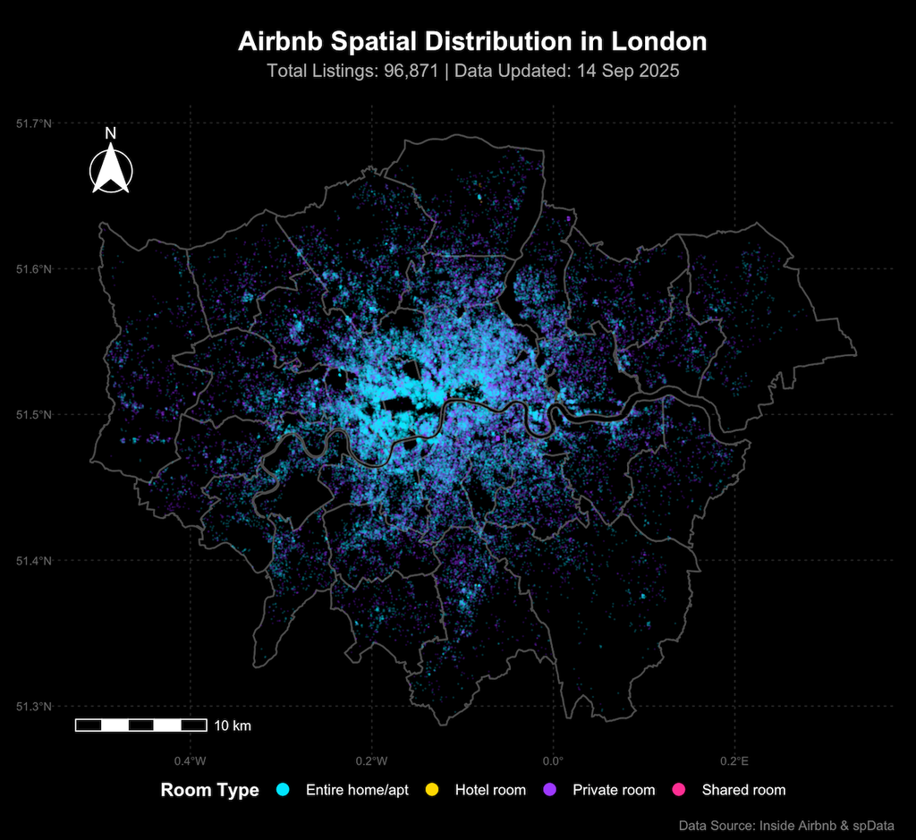

上述代码成果图1

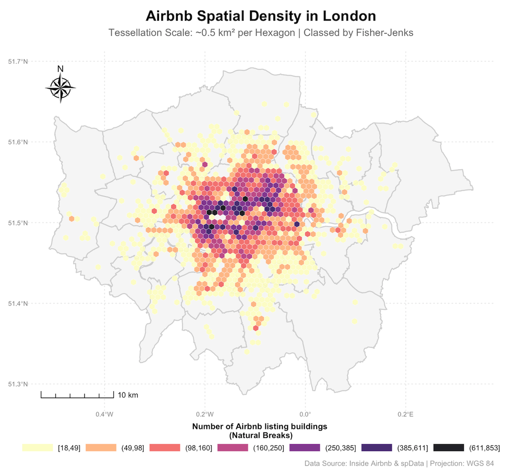

上述代码成果图2

##### **6.3 进阶代码挑战**

进阶练习

本节不提供参考代码。任务目标是：获取城市空间数据（可沿用伦敦数据，但鼓励探索其他国际大都市或中国代表性城市，如北京），完成一组**可用于研究报告或学术论文**的“微观空间聚合与分面可视化”。重点训练 **连续型变量映射 × 空间连接统计（Spatial Join） × 多维分面（Faceting）** 的综合空间表达能力。

###### **6.3.1 数据与研究问题**

**数据集**：目标城市的开源空间数据（建议访问 Inside Airbnb 获取）

**核心数据源与变量**：

- **矢量面数据**：目标城市的行政边界（可通过 `neighbourhoods.geojson` 读取）。
- **空间点数据**：目标城市完整房源切片（`listings.csv.gz`）。
- **核心分析变量**：
  - 空间属性：`longitude`, `latitude`
  - 评价属性：`review_scores_value`（性价比评分）或 `review_scores_rating`（综合评分）
  - 分组属性：`room_type`（房源类型）或 `host_is_superhost`（是否为超赞房东）

**研究问题**：  
- 在选定的大都市中，Airbnb 房客的综合满意度（评分）呈现何种微观空间分布特征？  
- 当采用**正方形网格（Square Tessellation）**平铺城市空间时，不同属性组别的**区域中位数评分**分布格局是否存在显著的空间异质性？

###### **6.3.2 可视化任务**

**任务 A｜微观空间点分布与离散化映射**（原始点分布图）  
- **数据获取与投影**：读取目标城市的房源点集与行政边界，剔除评分字段存在缺失值（`NA`）的无效观测。需客观查明并指定该城市适用的**局部投影坐标系**（Projected CRS），完成精确投影对齐。  
- **底图绘制**：在基础行政边界上叠加房源点要素，放弃简单的连续映射，要求采用**自然断点法**（Natural Breaks / Fisher-Jenks）或**分位数法**（Quantile）将评分变量离散化后再进行分层设色。同时需妥善配置点径与透明度，以缓解高密度区域的过度绘制问题。

**任务 B｜几何变换与空间聚合统计**（正方形密铺与中位数运算）  
- **网格划分**：基于目标城市边界，生成物理边长为 `500m`（或近似面积 0.25 km²）的**正方形空间网格**。  
- **空间频数计算与阈值清洗**：为消除极值偏差（如某网格仅有 1 个房源且评分为满分），**必须首先**执行空间相交运算（`st_intersects`）计算每个网格内的房源总数（Count），并严格剔除房源数量少于特定阈值（如 5 个或 10 个）的微弱信号地块。  
- **空间连接运算**（Spatial Join）：对保留下来的有效网格，利用点面拓扑关联将网格属性挂载至房源点上，进而分组计算每个正方形单元内所包含房源的**中位数评分**（Median Score）。

**任务 C｜高阶制图：分面网格特征图**（Faceted Choropleth）  
- **分组运算**：在空间连接与聚合阶段，引入分类属性变量（如房源类型），分别计算不同组别在各有效网格内的评分中位数。  
- **分面渲染**：使用 `facet_wrap()` 将不同组别的正方形网格地图并排输出。  
- **制图规范**：  
- 过滤无数据的网格（保持底图通透）。  
- 采用适宜的连续型或离散型渐变色盘（如 Viridis 序列）。  
- 图面需包含：严谨的标题、共享色带图例、比例尺、指北针及数据与投影说明。

###### **6.3.3 技术要求**

- 使用 **R Markdown** 完成，并 `knit` 输出为 **HTML**。
- 文档需包含：
  1. 数据获取逻辑与清洗准则（需说明缺失值与离群值的处理依据）。
  2. 作图代码（结构清晰，核心拓扑运算步骤需分段注释）。
  3. 简短文字解读（2–4 句）：提炼该城市高分房源的核心空间聚集区，并对比不同分面组别间的空间分布差异。
- 代码注释要求：
  - 必须说明选定局部投影坐标系（EPSG）的客观依据。
  - 说明网格样本量过滤阈值的设定理由。

#### **提示**

- **正方形网格构建**：在网格生成函数中指定相关参数（如 `square = TRUE`）即可生成正方形单元。
- **属性统计与空间关联范式**：面对“求特定多边形内点要素中位数”的需求，单一的空间相交计数运算无法实现。建议遵循“**空间关系传递 $\rightarrow$ 属性表分组聚合 $\rightarrow$ 几何对象挂载**”的分析范式：首先利用空间连接操作将正方形网格的唯一标识符（ID）映射至每个微观房源点位上；随后在点数据集中，按网格 ID 与目标分组变量执行常规的分组汇总运算（Group-by Summary）；最终将计算得出的统计量以属性表连接（Attribute Join）的方式匹配回原始的正方形网格几何对象中。
- **投影陷阱预警**：生成基于物理距离（米）的网格前，必须避开地理坐标系（如 WGS 84）。请查阅目标城市的平面投影（例如北京常采用 CGCS2000 投影系，具体视经度带而定）。